# Risk Radar Walkthrough

### Author: Paddy Moreau

# Intoduction

This document explains my approach to creating a prototype Risk Radar product. My focus, given the time contraints, was to build a working solution that could be improved upon in the future. Thus, I spent a decent chunk of the time understanding the available data and considering how best to present the findings to the end user. I wanted to ensure that the user could actually make decisions based on the insights that I presented them with.

Given the small amount of available time, I didn't leave much time for measurable experimentation. Given the opportunity, this would be the thing that I would discuss in more detail in an on-site interview. Rather, my priority was choosing techniques that I felt would likely satisfy the contraints that were present (i.e. lack of labelled data, no end-user design partner, latency matters, explainability).

Anyway, the Risk Radar product was good fun to work on and hopefully we can discuss it in more detail later.

[figure not shown]

```python
from IPython.display import Image
Image("screenshots/Screenshot 2026-02-20 at 09.36.58.png")
```

## Problem Framing

**Overall Goal:**

- Convert noisy social content into entity-specific risk narratives that analysts can triage quickly and confidently.

**Core Challenge Areas:**

- Ambiguity in entity mentions
- Heavy noise and weak-signal posts
- Narrative fragmentation across many posts
- Need for explainable (not opaque) risk ranking
- Presenting the data in an understabl way to the end-user, allowing them to decision on it
- The analysis needs to be completed reasonably quickly, considering the scale of data in a production solution

## Approach to Problem Solving

- I tried to put myself in the shoes of the end user and considered the type of data that they would like to be presented with. I delved into the raw datasets and inspected them manually as well as ran some simple investigations in a Python notebook to understand the nuances of the data. I toyed around with various data visualisations to consider what the end-user might be able to action on.
- Considering the size and noise of the dataset, I decided to use staged (gradual) signal refinement. I moved from simple, cheap gates, to more expensive and accurate ones. This was to ensure that our solution was still somewhat fast, while not sacrificing too much accuracy in our final analysis. I considering solutions in the past that I've built for NLP and did some basic research to see any SOTA approaches available.
- I chose to pre-compute all processed data before the UI displays, so that the end-user can have a snappy experience. Also introduced some caching in the frontend to support that goal too.
- I wanted to use LLMs where possible on the highly relevant, risky posts. As I knew this was going to be quite expensive, I ensured that we only applied this to the posts which were risky and relevant (by applying the filtering gates I mentioned above). Furthermore, I only applied the LLM to a substring of these relevant posts, focussing on the area around the matched entity. I wanted to involve LLMs because of their incredible strength in textual understanding and summarisation.
- I didn't spend too much time on tinkering with hyperparams of any of the models used, this would be something I would spend more time on if possible. For example, I chose an embedding model and a clustering approach based on a sensible default, rather than any sort of experimental approach.
- While I was keen to have a good UI for the end-user, I didn't want to use up a lot of time on it. Hence, I used AI coding tools to speed up the coding process for both the frontend and backend code. I keenly reviewed all the code, though, in order to make sure that it was following my instructions for the data pipeline.

# The Data Pipeline

This section is the technical core of the notebook.

For each pipeline step, we document:

- **Functionality**: what the step does and what it outputs.
- **Design reason**: why this method was chosen over alternatives.
- **Alternatives considered**: viable options and why they were not selected for this version.
- **Performance/tradeoffs**: latency, compute cost, and quality implications.
- **Failure modes**: where the step can fail and typical symptom patterns.
- **Evaluation approach**: how to measure if the step is healthy.
- **Explainability**: what evidence/artifacts are preserved for audit and analyst trust.

A key principle is **early cheap filtering, later expensive intelligence**:

1. use lightweight deterministic methods to reduce noise first,
2. apply LLM/embedding-heavy steps only to narrowed candidate rows,
3. persist stage outputs so page refreshes do not re-run expensive processing.

This ordering is the main reason the system stays tractable as data volume grows.

```python
from pathlib import Path
import json
import ast
import pandas as pd
import plotly.express as px
import plotly.io as pio
pio.renderers.default = "png"

BASE = Path('.')
DATA = BASE / 'data'
PROC = DATA / 'processed'

def read_jsonl(path: Path):
    if not path.exists() or path.stat().st_size == 0:
        return pd.DataFrame()
    return pd.read_json(path, lines=True)

def read_json(path: Path):
    if not path.exists() or path.stat().st_size == 0:
        return []
    with open(path, 'r', encoding='utf-8') as f:
        return json.load(f)

raw_posts = read_jsonl(DATA / 'posts.jsonl')
resolved_posts = read_jsonl(PROC / 'resolved_posts.jsonl')
filtered_out_posts = read_jsonl(PROC / 'filtered_out_posts.jsonl')
filtered_out_entity_rows = read_jsonl(PROC / 'filtered_out_entity_rows.jsonl')
clustered_posts = read_jsonl(PROC / 'clustered_posts.jsonl')
narratives = read_json(PROC / 'narratives.json')
narrative_df = pd.DataFrame(narratives)

print('raw_posts:', raw_posts.shape)
print('resolved_posts:', resolved_posts.shape)
print('filtered_out_posts:', filtered_out_posts.shape)
print('filtered_out_entity_rows:', filtered_out_entity_rows.shape)
print('clustered_posts:', clustered_posts.shape)
print('narratives:', len(narratives))
```

```
raw_posts: (1000, 12)
resolved_posts: (278, 16)
filtered_out_posts: (722, 15)
filtered_out_entity_rows: (219, 20)
clustered_posts: (100, 24)
narratives: 37
```

### Pipeline Stage 1: Prefiltering

**Functionality**

- Remove obviously low-value rows before expensive steps (long-text and sentiment-based gates).
- Output two things: rows that proceed, and rows dropped with reasons.

**Design reason**

- This stage is intentionally lightweight and deterministic.
- It protects downstream LLM + embedding stages from being flooded by low-signal content.
- It lowers run time and cost while improving precision for later clustering.

**Alternatives considered (and why not chosen here)**

- **No prefiltering**: highest recall, but very expensive and noisier narratives.
- **Embedding-only prefilter**: better semantic nuance, but too costly early in pipeline.
- **Classifier-based prefilter**: potentially stronger quality, but requires labeled training data and retraining lifecycle.

**Performance and tradeoffs**

- Deterministic prefiltering is very fast and scales linearly.
- Tradeoff: can remove subtle risk posts (recall hit), especially neutral-toned but relevant content.
- Practical strategy: keep this stage conservative enough to protect cost, then monitor false-negative rates.

**Failure modes**

- Over-filtering true risk signals.
- Under-filtering noisy rows, causing expensive downstream waste.
- Schema drift causing drop reason fields to become inconsistent.

**Evaluation approach**

- Track funnel pass/drop rates over time.
- Manually review random dropped sample for missed-risk rate.
- Monitor per-platform and per-entity skew to detect biased dropping.

**Explainability**

- Persist dropped rows with explicit `drop_reason` where available.
- Keep stage-level counts so decisions are auditable and reproducible.

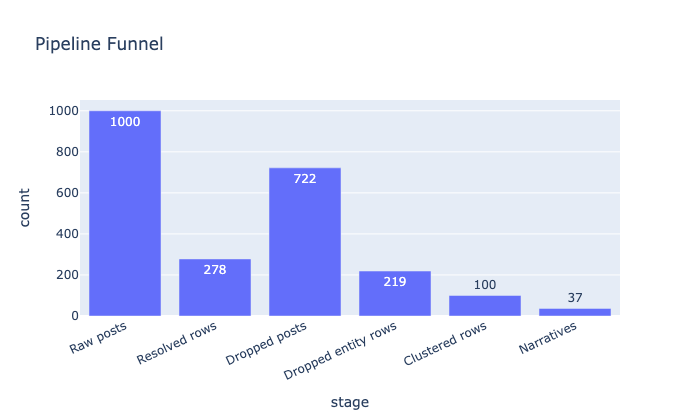

```python
funnel = {
    'Raw posts': len(raw_posts),
    'Resolved rows': len(resolved_posts),
    'Dropped posts': len(filtered_out_posts),
    'Dropped entity rows': len(filtered_out_entity_rows),
    'Clustered rows': len(clustered_posts),
    'Narratives': len(narratives),
}
funnel_df = pd.DataFrame({'stage': list(funnel.keys()), 'count': list(funnel.values())})
fig = px.bar(funnel_df, x='stage', y='count', text='count', title='Pipeline Funnel')
fig.update_layout(height=420, xaxis_tickangle=-25)
fig.show()
```

### Pipeline Stage 2: Entity resolution

**Functionality**

- Link each post to one or more candidate entities using layered matching:
  1. exact canonical match,
  2. alias match,
  3. fuzzy fallback.
- Produce post-entity rows with `resolution_method`, mention text, and confidence.

**Design reason**

- Layered matching gives a strong balance: precision-first exact/alias, then controlled recall via fuzzy.
- It avoids jumping directly to expensive semantic/LLM entity linking for every row.

**Alternatives considered (and why not chosen here)**

- **LLM-only entity resolution**: handles nuance but too slow/costly and harder to calibrate consistency.
- **Embedding nearest-neighbor entity linking**: strong for semantic aliases, but weaker interpretability and more complex threshold tuning.
- **Rules-only exact matching**: very fast and explainable, but low recall with noisy social text.

**Performance and tradeoffs**

- Exact/alias steps are cheap and scale well.
- Fuzzy improves recall but increases false-positive risk and CPU time.
- Main tradeoff: broader alias/fuzzy thresholds improve coverage but can pollute downstream narratives.

**Failure modes**

- Alias collisions (short tokens matching unrelated content).
- Fuzzy drift when distance thresholds are too permissive.
- Under-recall for emerging spellings/slang not in alias tables.

**Evaluation approach**

- Compute precision/recall by method on labeled samples.
- Slice errors by entity, platform, and mention type.
- Track confidence calibration (confidence deciles vs observed correctness).

**Explainability**

- Persist method, confidence, and mention evidence per row.
- Keep method-level distribution dashboards for QA and governance.

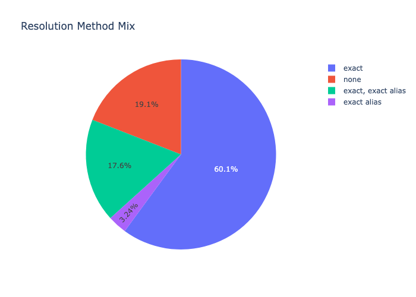

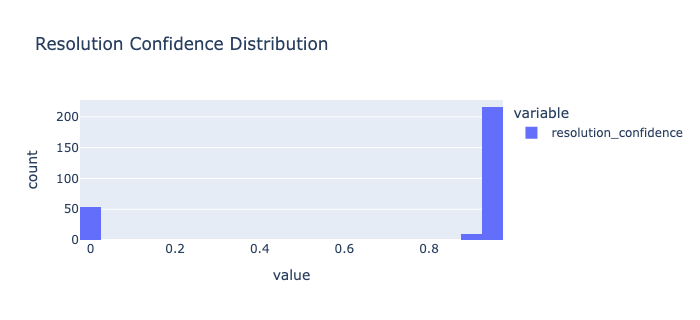

```python
if not resolved_posts.empty and 'resolution_method' in resolved_posts.columns:
    m = resolved_posts['resolution_method'].fillna('unknown').value_counts().reset_index()
    m.columns = ['method', 'count']
    px.pie(m, names='method', values='count', title='Resolution Method Mix').show()

if not resolved_posts.empty and 'resolution_confidence' in resolved_posts.columns:
    c = pd.to_numeric(resolved_posts['resolution_confidence'], errors='coerce').dropna()
    if len(c) > 0:
        fig = px.histogram(c, nbins=25, title='Resolution Confidence Distribution')
        fig.update_layout(height=320)
        fig.show()
```

### Pipeline Stage 3: Risk gating + row summaries

**Functionality**

- For each post-entity row, determine whether the content contains a real entity-relevant risk signal.
- Generate a concise, specific row-level risk summary for rows that pass. We use an LLM for this because of the accuracy needed. We use a fast LLM for this (gpt 4.1 nano) as we care about speed.
- These summaries become the semantic input for clustering.

**Design reason**

- This is the highest-impact precision gate in the pipeline.
- Without this gate, clustering often groups generic negative chatter rather than entity risk narratives.
- Structured summaries reduce lexical noise and improve embedding quality.

**Alternatives considered (and why not chosen here)**

- **Keyword-based risk gating only**: fast and deterministic, but low recall for nuanced or indirect risk language.
- **Sentiment-only gating**: cheap but too coarse; negative sentiment is not equivalent to risk.
- **Cluster-first then classify clusters**: can work, but tends to produce noisy clusters and wastes compute.

**Performance and tradeoffs**

- This is one of the slower stages because it uses LLM calls.
- Batching reduces overhead but can increase parse/validation failure complexity.
- Tradeoff: strict validation improves quality but can drop rows when model output is malformed.

**Failure modes**

- Generic summaries that do not preserve entity-specific claim content.
- JSON formatting failures or retries exhausted.
- False negatives on subtle, coded, or context-heavy risk statements.

**Evaluation approach**

- Labeled risk/non-risk sample for precision and recall.
- Quality rubric on generated summaries: specificity, entity alignment, and actionability.
- Operational metrics: retry rate, parse failure rate, average latency per batch.

**Explainability**

- Persist risk decision + summary text per row.
- Keep drop reasons for rejected rows to support debugging and audit traceability.

### Pipeline Stage 4: Clustering

**Functionality**

- Embed row-level risk summaries and group semantically similar rows into narratives. We use the risk summaries which were generated for each post by the LLM rather than the overall post.
- This is because we want the embedding distance to focus on the risk, rather than some other semantic or stylistic feature of the text.
- Output narrative assignments that connect many posts into coherent risk themes.

**Design reason**

- Analyst workflows require narrative-level units, not isolated posts.
- Embedding-based clustering captures semantic similarity across paraphrases and lexical variation.

**Alternatives considered (and why not chosen here)**

- **TF-IDF + KMeans only**: very fast and simple, but weaker semantic grouping for paraphrased claims.
- **Topic modeling (LDA/NMF)**: interpretable topics, but often less precise for short/noisy social snippets.
- **End-to-end LLM clustering**: potentially high quality but expensive, slower, and harder to make deterministic.

**Performance and tradeoffs**

- Embeddings are costlier than TF-IDF but materially improve narrative coherence.
- Dense clustering can over-fragment if parameters are too strict.
- Tradeoff: tighter clusters improve purity but may split one narrative into multiple near-duplicate groups.

**Failure modes**

- Fragmented tiny clusters (over-clustering).
- Mixed-theme clusters (under-clustering).
- Instability when input distribution shifts between runs.

**Evaluation approach**

- Quantitative: cluster-size distribution, silhouette/cohesion-style diagnostics where feasible.
- Qualitative: sampled cluster review for semantic purity and title faithfulness.
- Stability: compare cluster assignments and narrative counts across adjacent runs.

**Explainability**

- Persist post-to-narrative lineage.
- Preserve representative summaries/examples per cluster for analyst audit.

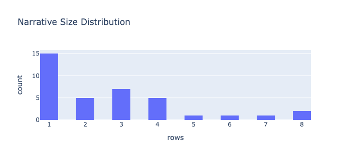

```python
if not clustered_posts.empty and 'narrative_id' in clustered_posts.columns:
    s = clustered_posts.groupby('narrative_id').size().reset_index(name='rows')
    fig = px.histogram(s, x='rows', nbins=25, title='Narrative Size Distribution')
    fig.update_layout(height=320)
    fig.show()
```

### Pipeline Stage 5: Scoring + explainability

**Functionality**

- Compute a 0-100 narrative risk score from interpretable components (volume, engagement, author influence, taxonomy language signals).
- Compute a separate risk confidence label. This is very simple, solely based on matching confidences and volume.
- We use handcrafted weights for the model calculation, guaranteeing explainability and bounds from 0-100.
- Persist component-level contributions for driver charts.

**Design reason**

- Product needs a ranking signal for triage and a transparent explanation for trust.
- Separating severity (score) from certainty (confidence) prevents conflating impact with reliability.

**Alternatives considered (and why not chosen here)**

- **Black-box model score (single learned output)**: potentially stronger predictive power, but low interpretability and harder governance.
- **Rule-only threshold score**: easy to explain, but brittle and difficult to calibrate across entities/time.
- **Confidence merged into score**: simpler display but less honest about uncertainty and can mis-rank narratives.

**Performance and tradeoffs**

- Deterministic scoring is fast and cheap once inputs are prepared.
- Tradeoff is calibration burden: weights and thresholds require periodic tuning.
- Overweighting one feature can create unstable ranking behavior under spikes.

**Failure modes**

- Poorly calibrated component weights.
- Score inflation during short-lived volume bursts.
- Confidence labels that do not match observed matching quality.

**Evaluation approach**

- Compare ranked outputs against analyst triage outcomes.
- Backtest over historical windows for ranking stability.
- Sensitivity tests: perturb component weights and observe rank churn.

**Explainability**

- Persist component contributions, taxonomy labels, and confidence labels.
- Make each score reproducible from saved intermediate artifacts.

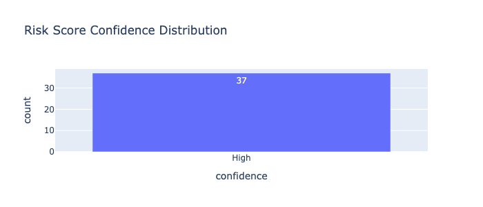

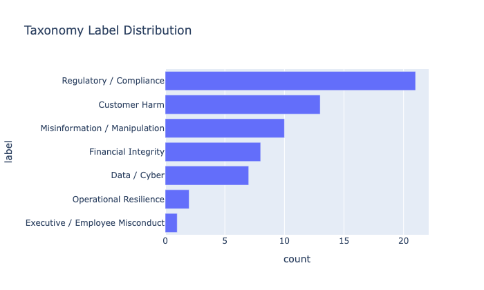

```python
if not narrative_df.empty and 'risk_score' in narrative_df.columns:
    rs = pd.to_numeric(narrative_df['risk_score'], errors='coerce').dropna()
    if len(rs) > 0:
        fig = px.histogram(rs, nbins=20, title='Narrative Risk Score Distribution (0-100)')
        fig.update_layout(height=320)
        fig.show()

if not narrative_df.empty and 'risk_score_confidence' in narrative_df.columns:
    c = narrative_df['risk_score_confidence'].fillna('unknown').value_counts().reset_index()
    c.columns = ['confidence', 'count']
    fig = px.bar(c, x='confidence', y='count', text='count', title='Risk Score Confidence Distribution')
    fig.update_layout(height=300)
    fig.show()

if not narrative_df.empty and 'taxonomy_labels' in narrative_df.columns:
    def parse_labels(x):
        if isinstance(x, list):
            return x
        if pd.isna(x):
            return []
        s = str(x).strip()
        if not s:
            return []
        try:
            v = ast.literal_eval(s)
            if isinstance(v, list):
                return [str(i) for i in v]
        except Exception:
            pass
        return [s]
    labels = [lab for row in narrative_df['taxonomy_labels'].apply(parse_labels) for lab in row]
    if labels:
        lc = pd.Series(labels, name='label').value_counts().reset_index()
        lc.columns = ['label', 'count']
        fig = px.bar(lc.sort_values('count', ascending=True), x='count', y='label', orientation='h', title='Taxonomy Label Distribution')
        fig.update_layout(height=420)
        fig.show()
```

[output not shown]

### Pipeline Stage 6: End-to-end tradeoffs and performance budget

**Why this pipeline order matters**

- Early stages are intentionally cheap and high-throughput.
- Middle stages (LLM/embeddings) are expensive and therefore run on a reduced candidate set.
- Final stages (scoring/aggregation) are cheap again and optimized for repeat reads.

**Indicative performance profile**

- Prefiltering + deterministic matching: low latency, CPU-bound.
- LLM risk gating + summarization: highest latency, external API-bound.
- Embeddings + clustering: medium-high latency, vector compute-bound.
- Scoring + artifact writes: low latency, mostly I/O + simple arithmetic.

**Global alternatives considered**

- **Single end-to-end LLM pipeline:** highest semantic flexibility, but expensive and hard to make reproducible.
- **Fully deterministic pipeline:** fastest and easiest to audit, but lower quality on nuanced language.
- **Hybrid (current):** deterministic narrowing plus targeted model use for quality-critical tasks.

**Cross-stage tradeoffs**

- Precision vs recall: stricter gating improves quality but may miss weak signals.
- Cost vs fidelity: richer model usage improves nuance but increases run cost and runtime.
- Freshness vs stability: frequent rebuilds improve timeliness but can cause narrative churn.

**Recommended monitoring KPIs**

- Stage durations and p95 run time.
- Drop/pass rates by stage and by entity.
- Retry and parse-failure rates for model stages.
- Narrative churn rate between consecutive runs.
- Cost per run and cost per kept narrative.

## Assumptions Made

### Data and labeling assumptions

- Source posts are representative enough to infer emerging entity-risk narratives.
- Entity seed and alias lists are sufficiently maintained to avoid major recall gaps.
- Engagement and author metrics are directionally useful, even if not perfectly complete.

### Modeling assumptions

- Risk is better represented as a staged filtering + enrichment process than a single monolithic model.
- Entity-specific risk summaries provide better clustering inputs than raw post text.
- LLM-assisted stages are useful when constrained by strict output validation.
- LLM only got to see substrings, could be missing important context outside of that substirng.

### Product assumptions

- Analysts prefer higher precision over maximal recall in first-pass triage.
- A transparent but imperfect score is more useful than a high-performing opaque score.
- Confidence must be communicated separately from severity to reduce misuse.

### Operational assumptions

- Processed artifacts are the serving source of truth between explicit rebuilds.
- Refresh should load persisted artifacts rather than rerun heavy processing.
- Pipeline stage metrics and drop reasons are required for support/debug workflows.

### Governance assumptions

- Risk score is a prioritization aid, not a legal or factual determination.
- Human review is required for high-impact actions.
- Auditability (lineage, reasons, versions) is a core requirement, not an optional feature.

## Future Production plan

### High-level AWS architecture

- **Storage:** S3 buckets for raw inputs, processed artifacts, and run manifests.
- **Orchestration:** Step Functions to coordinate stages, retries, and status transitions.
- **Compute:** ECS Fargate or AWS Batch for pipeline jobs (containerized and versioned).
- **Serving path:** lightweight API layer for dashboard/narrative reads, backed by cached artifacts.
- **Caching:** Redis/ElastiCache for hot queries and frequently accessed aggregates.
- **Observability:** CloudWatch logs/metrics/alarms with stage-level SLA thresholds.
- **Secrets and security:** Secrets Manager for keys, IAM least privilege, encryption in transit and at rest.

### Why this architecture

- Separates offline heavy processing from online interactive reads.
- Keeps expensive LLM/embedding work out of request-time paths.
- Enables deterministic rebuilds and reproducible rollbacks via artifact versioning.

### Performance and scaling strategy

- Partition processing by time window and/or entity to parallelize safely.
- Batch LLM and embedding calls with bounded concurrency.
- Persist stage outputs to avoid recomputation on retries.
- Use artifact signatures to load cache only when inputs and versions match.

### Tradeoffs and alternatives

- **All-in-one app server pipeline execution:** simpler setup, but poor isolation and user-visible latency spikes.
- **Serverless-only approach (Lambda-heavy):** operationally simple for small jobs, but can struggle with long-running ML/LLM stages.
- **Fully managed ML stack (SageMaker pipelines):** powerful for mature ML ops, but heavier platform overhead for this phase.

### Reliability, governance, and cost controls

- Stage timeouts, retry budgets, and dead-letter handling for failed batches.
- Build manifests capturing model versions, prompt versions, row counts, and checksums.
- Cost guardrails: max rows per run, dynamic batch sizing, and run cancellation policies.
- Access controls and immutable audit logs for compliance and incident review.

### Deployment phases

1. **Phase 1:** single-region baseline with manual rebuild control.
2. **Phase 2:** scheduled incremental rebuilds + quality report generation.
3. **Phase 3:** multi-environment promotion (dev/staging/prod) with artifact promotion gates.

## Future Steps

2-4 week plan:

1. build labeled evaluation sets,
2. add run-quality and drift reports,
3. calibrate score weights and confidence bands,
4. improve audit metadata and lineage,
5. implement analyst feedback loop,
6. harden reliability and artifact validation.